# Un primer acercamiento al análisis de datos aplicado al fútbol

Diego Aravena

Diciembre 2021

# Introducción

En la mayoría de los deportes los competidores hacen uso de estrategias especializadas para lograr obtener la victoria. Aquello toma un rol vital en los deportes colectivos, tan solo imagine la cantidad de instrucciones que un entrenador les tiene que dar a sus jugadores por cada partido. La persona encargada de dirigir al equipo debe tomar las mejores decisiones en base a las capacidades de cada jugador, algo que no es del todo fácil si no se tienen las herramientas necesarias. Sin embargo, el paso del tiempo a beneficiado a una gran cantidad de deportes, y un ejemplo claro es el futbol. Desde que apareció el internet se abrió una fuente llena de posibilidades para el almacenamiento de los datos, dando nombre a lo que vendría siendo el ícono de esta nueva era, el “Big Data”.

Comprender el comportamiento de las acciones realizadas dentro del campo de juego por los jugadores, toma un rol vital al momento de tomar decisiones. El hecho de que equipos con pocas inversiones en sus jugadores y equipo técnico, hayan logrado salir campeones gracias al uso del Big Data son un claro ejemplo de lo que es capaz esta nueva tecnología. Por otro lado, equipos con un altísimo rendimiento y enormes fuentes de dinero, son conscientes que para lograr mantenerse en los primeros lugares es fundamental tener la más avanzada tecnlogía. Hoy en día muchos equipos utilizan la estadística para analizar sus partidos con el objetivo de aprender en base a los datos que son generados en cada uno de ellos. Cualquier hecho relevante que pueda ocurrir durante un partido se considera como un dato y este es almacenado en la nube para posteriormente ser analizado.

El objetivo principal de este informe es analizar las estadísticas de los clubes Real Madrid y FC Barcelona que además poseen a los dos jugadores más destacados del fútbol moderno, Cristiano Ronaldo y Lionel Messi. La principal motivación es conocer y comprender el desarrollo de ambos clubes en términos de rendimiento durante un cierto período de tiempo y poder también asociar las actuaciones de los jugadores mencionados para cuantificar el aporte de cada uno a sus equipos. Por otro lado, se busca analizar un caso particular ocurrido en la primera división de la liga inglesa en la temporada 2015/2016 donde el equipo ganador de ese período corresponde al Leicester City.

Se estudiará el progreso que tuvieron ambos equipos españoles durante las 5 temporadas, esto con el fin de poder analizar su rendimiento. Y para el caso del equipo inglés se analizará su llegada en la temporada 2014-2015 y la 2015-2016 que es donde logra salir campeón. A estos tres equipos se le hará una mirada global (comparando con todos los demás equipos) sobre aspectos de los rendimientos de cada uno. Del mismo modo, se estudiarán los comportamientos de los jugadores más importantes para conocerlos más allá de sus habilidades, y así quizás comprender mejor el motivo de su buen desempeño. Estos estudios se organizarán en dos secciones, la primera sección estudiará el desempeño del equipo inglés y en la segunda a los dos equipos españoles.

# Antecedentes

Real Madrid y Barcelona son los clubes que más veces han sido catalogados como los mejores del mundo según el [ránking](https://es.wikipedia.org/wiki/Clasificaci%C3%B3n_mundial_de_clubes_seg%C3%BAn_la_IFFHS) realizado por la IFFHS (Federación Internacional de Historia y Estadística de Fútbol). Asímismo estos poseen a los mejores jugadores del mundo de aquella fecha, pues Lionel Messi acumulaba 5 [balones de oro](https://es.wikipedia.org/wiki/Bal%C3%B3n_de_Oro) hasta el año 2015. Este es un premio individual que se otorga todos los años al jugador con el mejor rendimiento tanto a nivel de clubes como de selección. Y por otro lado, detrás de Messi venía Cristiano Ronaldo que lograba acumular 3 balones de oro.

El año 2014 el equipo Leicester City lograba subir a la primera división de la liga inglesa después de una ausencia de 10 años, aunque al término de la temporada casi desciende nuevamente. Sin embargo, luego de haberse salvado del descenso, en la siguiente temporada se vino la mayor sorpresa que ha tenido la liga inglesa, pues un equipo con este perfil habría obtenido el primer lugar de la liga. Esta vendría siendo su primera victoria en la *Premier League* tras 132 años de existencia.

Algo a considerar es que las temporadas duran aproximadamente 9 meses y estas parten generalmente en el mes de Agosto. Por lo tanto, la temporada 2011-2012 (por ejemplo) se puede denotar como la temporada del año 2011. Esto puede llegar a ser útil para comprender algunos aspectos de este informe.

# Base de datos

Para la realización de este informe se utiliza una [base de datos](https://www.kaggle.com/secareanualin/football-events) provenientes de la página gratuita *Kaggle* que permite acceder a un enorme repositorio de datos publicados por la comunidad. Más especificamente, los datos utilizados son gracias al trabajo realizado por el usuario *Alin Secareanu*, que logra formarlos utilizando métodos de *webscraping* e integrando diferentes fuentes. Como resultado, este conjunto de datos proporciona una vista granular de 9.074 juegos de fútbol, que van desde la temporada 2011/2012 hasta la temporada 2016/2017, llegando a un total de 941.009 eventos de las 5 ligas de fútbol más importantes del mundo: Inglaterra, España, Alemania, Italia y Francia.

En este trabajo nos enfocaremos en el caso particular ocurrido con el equipo Leicester City, si bien la temporada anterior a la de ganar el título recién lograban subir a la primera división de la liga inglesa, es gran interés poder ver la evolución que tuvo este equipo durante ese año. Y, por otro lado, se analizarán los datos del Fútbol club Barcelona y Real Madrid, provenientes de la primera división de España, enfocándose en las temporadas 2011-2012 hasta la 2015-2016 de La Liga.

Este contiene 3 grandes archivos:

- events.csv: contiene los datos de cada partido.
- ginf.csv: contiene metadatos y probabildades de mercado de cada partido.
- dictionary.txt: diccionario con la descripción de cada variable asignada en cada categoría en el archivo *events.csv*

**Las variables del archivo *events.csv* se detallan a continuación:**

| Variable | Descripcion |
| --- | --- |
| id_odsp | Identificador único de cada partido |
| id_event | Identificador único de cada evento (id_odsp + sort_order) |
| sort_order | Orden cronológico de los eventos en cada partido |
| time | Minuto del juego |
| text | Comentario de texto acerca del evento ocurrido |
| event_type | Evento principal |
| event_type2 | Evento secundario |
| side | Lado del campo |
| event_team | Equipo que comete el evento |
| opponent | Equipo contrario |
| player | Jugador principal |
| player2 | Jugador secundario |
| player_in | Jugador entrante (sustitución) |
| player_out | Jugador que sale (sustitución) |
| shot_place | Dirección hacia la que va dirigido el balón |
| shot_outcome | Resultado del tiro |
| is_goal | Indica si el tiro es gol |
| location | Ubicación en el campo donde ocurre el evento |
| bodypart | Parte del cuerpo que acciona el evento |
| assist_method | Método de asistencia |
| situation | Situación de juego |
| fast_break | Descanso rápido |

**El archivo *dictionary.txt* detalla los valores que toman algunas variables:**

| Variable | Valores_que_toma |
| --- | --- |
| event_type | 1-Intento 2-Tiro de esquina 3-Falta 4-Tarjeta amarilla 5-Segunda tarjeta amarilla 6-Tarjeta roja 7-Sustitución 8-Tiro libre obtenido 9-Fuera de juego 10-Mano 11-Penalti concedido |
| event_type2 | 12-Pase clave 13-Balón fallido 14-Expulsión 15-Autogol |
| side | 1-Local 2-Visita |
| shot_place | 1-Un poco alto 2-Bloqueado 3-Esquina inferior izquierda 4-Esquina inferior derecha 5-Centro de la portería 6-Alto y ancho 7-Pega en el palo 8-Falla a la izquierda 9-Falla a la derecha 10-Muy alto 11-C… |
| shot_outcome | 1-A portería 2-Afuera 3-Bloqueado 4-Pega en el palo |
| location | 1-Campo contrario 2-Campo propio 3-Centro del área 4-Banda izquierda 5-Banda derecha 6-Ángulo difícil y largo alcance 7-Ángulo difícil a la izquierda 8-Ángulo difícil a la derecha 9-Lado izquierdo del… |
| bodypart | 1-Pie derecho 2-Pie izquierdo 3-Cabeza |
| assist_method | 0-Ninguno 1-Pase 2-Centro 3-Pase de cabeza 4-Pase en profundidad |
| situation | 1-Jugada abierta 2-Balón parado 3-Tiro de esquina 4-Tiro libre |

**Por último el archivo *ginf.csv* posee:**

| Variables | Descripcion |
| --- | --- |
| id_odsp | Identificador único de cada partido |
| link_odsp | Link a la pagina de oddsportal del partido |
| adv_stats | Booleano indicando si el partido tiene eventos detallados |
| date | Fecha del partido |
| league | Liga |
| season | Temporada |
| country | País |
| ht | Equipo local |
| at | Equipo visita |
| fthg | Goles del equipo local |
| ftag | Goles del equipo visita |
| odd_h | Probabilidades de mercado de que el equipo local gane |
| odd_d | Probabilidades de mercado de que ambos equipos empaten |
| odd_a | Probabilidades de mercado de que el equipo visita gane |
| odd_over | Las probabilidades de mercado más altas de más de 2.5 |
| odd_under | Las probabilidades de mercado más altas por debajo de 2.5 |
| odd_bts | Probabilidades de mecado de que ambos equipos anoten |
| odd_bts_n | Probabilidades de mecado de que ambos equipos NO anoten |

Las descripciones se tradujeron al español, incluyendo los valores que poseen.

Finalmente, para efectos de este informe sólo se hará uso de la tabla *events.csv* donde posteriormente se le agregaron las columnas date, league y season mediante combinación de información con la tabla *ginf.csv*.

# Análisis de equipos

El siguiente informe se separa en dos partes. En un principio se partirá analizando los datos del equipo inglés, a modo de ir interpretando los eventos ocurridos durante su evolución. Y por último, a los dos equipos españoles, incluyendo una comparativa entre los deportistas Cristiano Ronaldo y Lionel Messi.

## Leicester city

La Premier League, también conocida en Inglaterra como The Premiership, es la máxima categoría del sistema de ligas de fútbol de Inglaterra.

En este primer análisis se partirá trabajando con los eventos ocurridos en la “Premiership” a lo largo de la temporada 2015-2016, enfocándonos en el equipo Leicester City, el cual obtuvo el primer lugar de la liga. Luego indagaremos sobre el rendimiento que tuvo este equipo comparándolo con el resto de los competidores.

Como todo equipo que viene de una categoría más baja, acostumbrarse a la categoría más competitiva que existe no es un reto fácil. Si bien en la temporada anterior (2014-2015) este logró subir recién a primera , nos interesa ver el progreso que tuvo en esa primera temporada con la siguiente, que es donde finalmente obtiene el primer lugar. Para poner en contexto, la temporada 2014-2015 la Premier League la ganó el equipo del Chelsea, superando al campeón anterior Manchester City. En las siguientes dos figuras analizaremos el ratio de goles que tuvo cada equipo en cada una de estas temporadas y veremos si existen algunas semejanzas con el primer lugar.

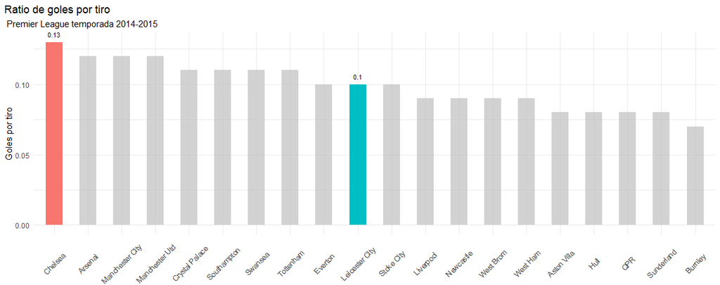

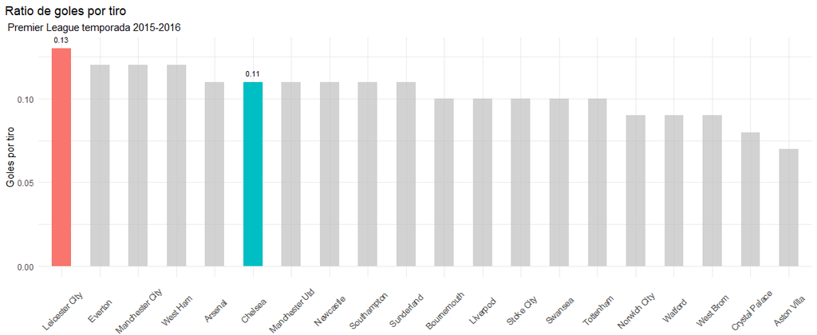

Lo primero que podemos observar es que ambos equipos (Chelsea y Leicester) tienen el mejor ratio de goles por tiro a portería, es decir, por cada tiro al arco que hacen tienen mayor probabilidad de que sea un gol. En ambos casos la probabilidad de marcar un gol dado cualquier intento que se realice es de un 13%. Por otro lado, vemos que nuestro equipo de interés tuvo un enorme progreso, pasando de estar dentro del promedio de goles por tiro entre todos los equipos a ser al equipo con mayor probabilidad de esta categoría.

Luego, dentro del mismo contexto se presentan las siguientes dos figuras, en las cuales se puede comparar la cantidad de goles por partido en las dos temporadas.

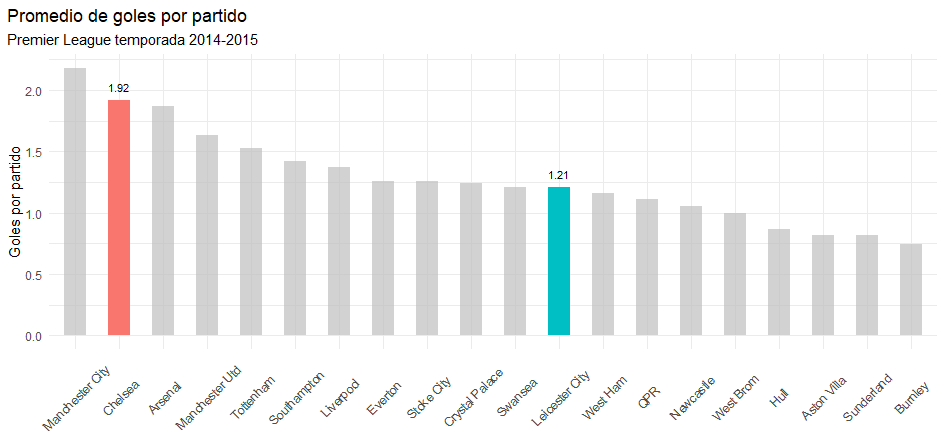

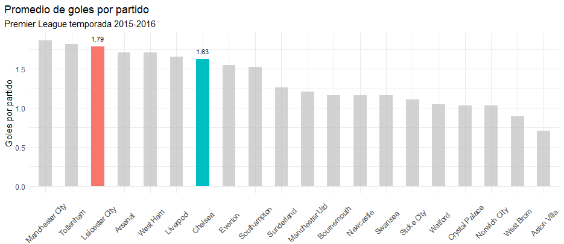

Aqui se puede observar que en en ambas temporadas ninguno de los dos equipos ganadores de la liga eran los equipos más goleadores, sin embargo, estos se mantienen dentro del top 3 en las respectivas temporadas. Es interesante también notar que, si bien el Manchester City ha obtenido el mejor rendimiento en las dos temporadas, no ha podido coronarse como campeón. Este salió segundo en la temporada 2014-2015 y cuarto en la temporada 2015-2016. Por lo tanto, podemos concluir que el hecho de tener la mayor cantidad de goles por partido no asegura que un equipo pueda salir campeón, pues para eso vale más la precisión de meter un gol por intento.

Ahora, centrándonos solo en la temporada 2015-2016 y en el equipo Leicester City, nos interesa averiguar los distintos comportamientos de los eventos más importantes al momento de marcar goles.

Sabemos que la probabilidad de marcar un gol dado que un jugador simplemente lo intente es de un 13%. Ahora nos interesa saber cuáles son las probabilidades de marcar un gol según el sector hacia el cual se dirige el tiro. Si bien estos no siempre se dirigen a portería, se filtró por todos los tiros que si iban dirigidos hacia dentro de ella, independiente si resultaba en gol o no. La siguiente figura muestra los resultados obtenidos

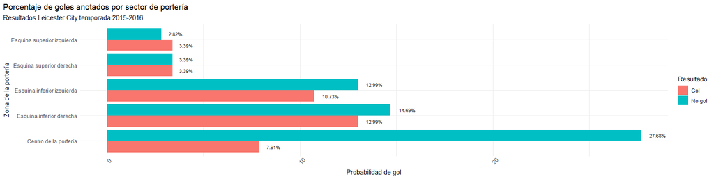

Los porcentajes están en base al total de tiros realizados hacia el total de las zonas indicadas en el gráfico. Luego se puede observar claramente que de todos los tiros a portería, un 35.59% de estos van dirigidos hacia el centro de ella, sin embargo, no es donde más probabilidad hay de marcar un gol, ya que la probabilidad llega a estar cercana al 8%. En cambio si nos fijamos en los tiros hacia las esquinas inferiores, la probabilidad de marcar un gol aumenta. El sector inferior izquierdo se lleva un 23.72% de los tiros totales, de los cuales el 45,2% de los tiros hacia ese sector resulta en gol. Por otro lado, en el sector derecho se agrupa un 27,68% de los tiros totales, y cerca de un 47% de ellos resulta en gol.

Otro aspecto importante de este hecho es la ubicación desde donde se lanza el balón y las situaciones de juego respectivas, puesto que las probabilidades de marcar un gol son distintas en cada ubicación del campo donde ocurre la jugada. Por este motivo, se creó una tabla que nos presenta el top 10 de cómo se lograron obtener los goles durante la temporada

| Ubicación del campo | Situación del juego | Método de asistencia | Cantidad de goles |
| --- | --- | --- | --- |
| Punto penal | Balón parado | Ninguno | 10 |
| Centro del área | Jugada abierta | Pase | 8 |
| Centro del área | Jugada abierta | Centro | 7 |
| Centro del área | Jugada abierta | Ninguno | 6 |
| Centro del área | Jugada abierta | Pase en profundidad | 5 |
| Centro del área | Balón parado | Centro | 3 |
| Lado izquierdo del área | Jugada abierta | Pase | 3 |
| Rango muy cercano | Jugada abierta | Pase | 3 |
| Centro del área | Balón parado | Pase | 2 |
| Centro del área | Tiro de esquina | Centro | 2 |

Se puede concluir que los futbolistas tenían un gran desarrollo colectivo, pues la mayoría de sus goles provienen de una jugada abierta, es decir, cuando la jugada no parte desde un balón parado como lo son los tiros libres, saques de meta, etc.

Además se puede deducir que no tenían jugadores con habilidades destacables en tiros libres, más bien estos suelen terminar en pases o centros. Estos últimos acumulan al menos 12 goles. Por lo tanto, se mantiene la postura en relación con que el equipo supo adaptarse colectivamente y gracias a eso trajo consigo una gran sorpresa como ya se había comentado.

Ahora interesa observar la cantidad de goles convertidos durante las temporadas y deducir cómo estos distribuyen para luego comprobar si es posible realizar inferencia en base a ello. Se analizará primero la temporada 2014-2015, tal como indica la siguiente figura

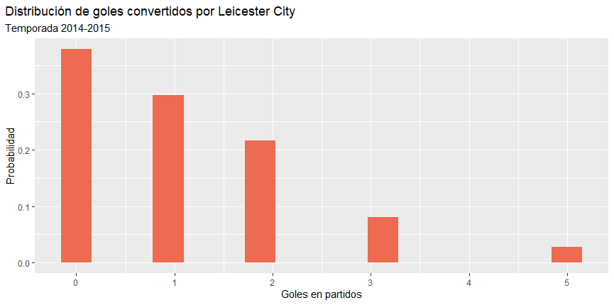

Se observa que la forma de la distribución es asimétrica con sesgo positivo, lo que hace notar una alta probabiidad de no marcar gol en un partido. Luego se percibe un decaimiento en las probabilidades a medida que la cantidad de goles aumenta, aunque pareciera tener un pequeño levantamiento en la cola. En este caso, la variable de interés registra un número de eventos por unidad de tiempo, por lo que podría ajustarse a una distribución poisson.

Luego, gracias a la función *goodfit()* del package *vcd*, se puede concluir que la cantidad de goles por partido sigue una distribución poisson con parámetro lambda = 1.222. Esto quiere decir que en base al registro de goles del Leicester City, este tiende a marcar en promedio 1 gol por partido, estando entre 0 y 2 goles prácticamente.

Para ser un equipo nuevo en la liga, esta cantidad de goles no es menor, pero ya se vio que durante esta temporada estuvo muy por debajo de los grandes equipos. Es por esto que ahora se desea ver si esta distribucion de goles mejora en la siguiente temporada analizando la siguiente figura

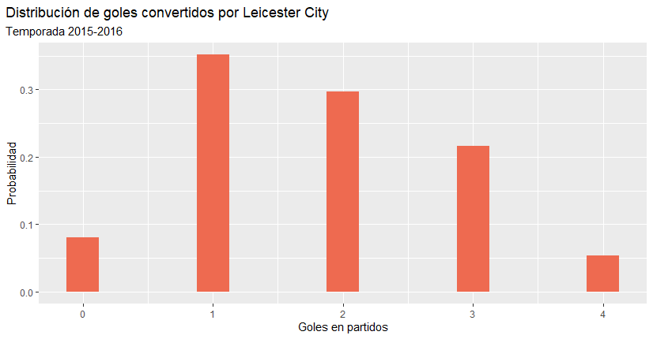

La diferencia es notoria, se puede ver como el mismo sesgo se traslada hacia el lado positivo del eje horizontal, lo que genera una cola pequeña al lado izquierdo de la curva. Esto es significativo, ya que hace referencia a que los goles goles por partido tienden ser más. A continuación, realizando la misma metodología que el caso anterior, mediante la funcion *goodfit()* se obtiene que la distribución se comporta como una poisson de parámetro lambda = 1.85.

Como se pudo observar, el progreso es destacable. Pasar de tener una media de 1 gol por partido a mantenerse cercano a los 2 goles o más, sin tener grandes estrellas en el equipo y teniendo un rendimiento de juego colectivo alto parece ser todo lo necesario para poder optar a ser campeón.

## Barcelona & Real Madrid

A continuación se realizará una comparativa entre los dos clubes más destacados de la liga española durante los años 2011 y 2016, período en el que se llevaron a cabo las 5 temporadas que se analizarán. Para poder ir asociando algunos resultados se debe tener en cuenta que los campeones de esos años

| Temporada | Campeón | Subcampeón |
| --- | --- | --- |
| 2011-2012 | Real Madrid | Barcelona |
| 2012-2013 | Barcelona | Real Madrid |
| 2013-2014 | Atlético Madrid | Barcelona |
| 2014-2015 | Barcelona | Real Madrid |
| 2015-2016 | Barcelona | Real Madrid |

De partida se analizará la evolución de ambos equipos durante las años 2011 y 2015 acerca de su rendimiento al momento de querer marcar goles. La siguiente figura sigue el índice de gol por tiro en las 5 temporadas de cada equipo que ha estado en la primera división de la liga, enfocándose en los dos equipos de interés.

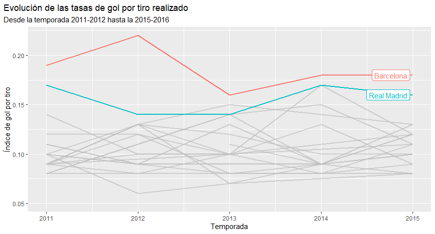

Es posible concluir que el barcelona es el líder indiscutido de estas 5 temporada en cuanto al ratio de goles por tiro, convirtiéndolo en el equipo más peligroso al momento de atacar. En sus mejores momentos la probabilidad de que uno de sus jugadores intentara marcar un gol era de un 22%, que corresponde a la temporada 2012-2013. Sin embargo, se aprecia que en la temporada siguiente tuvo una caída importante, llegando casi al 15% y pese a ello se mantenía en el valor más alto. Esa temporada logró salir 2do lugar de la liga y las siguientes dos se coronaría campeón consecutivo luego de ese bajón.

Por otro lado, el equipo que le seguía el paso era el real madrid. Aunque nunca logra superar a su contrincante, este tiende a tener mejor índice respecto a todos los demás equipos, pero nunca tanto como lo logró en su momento el barcelona. A medida que pasan los años no existe mucha variabilidad en sus índices de precisión, donde el punto más alto lo consigue en los años 2011 y 2014 con un 17%.

Ahora se quiere conocer la evolución que tuvieron estos equipos en cuanto a los goles convertidos en cada partido. En la siguiente figura se puede ver cómo varía el índice de gol por partido de todos los equipos que estuvieron en la liga.

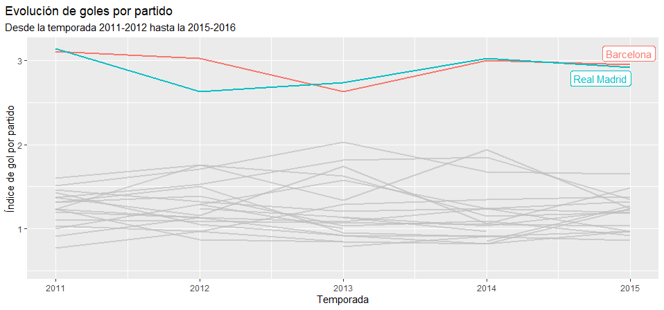

Pareciera que prácticamente ambos equipos compiten entre ellos, pues la competitividad que tienen es tal que logran obtener un promedio de aproximadamente 3 goles durante 5 temporadas consecutivas. Mientras tanto, el promedio de los demás equipos ronda entre 1 y 2 goles por partido.

Ahora analizando en detalle el gráfico, es posible ver también un bajón en el promedio de goles del barcelona en la temporada 2013-2014, lo cual se puede asociar con la disminución en el índice de precisión visto anteriormente. Por otro lado, se ve que el real madrid parte en lo alto y un año después, el 2012 la cantidad de goles disminuye. Luego, este tarda 2 temporadas en volver a subir su índice, y justo en ese período de recuperación se puede notar que al barcelona le toma solo 1 año desde su bajón en el 2013.

Si bien, los goles por partido no parecieran tener mucha variabilidad, lo que interesa ahora es conocer su distribución. Para los dos equipos se espera que los resultados tengan un comportamiento similar al de una poisson, tal como se vio anteriormente.

En la siguiente figura se muestra la distribución de los goles convertidos por el barcelona durante aquellos años.

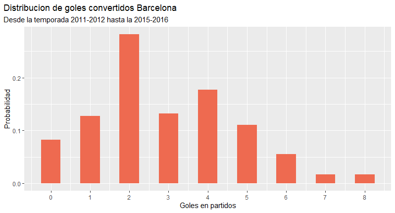

Siendo el turno del siguiente equipo, en el siguiente gráfico se presenta el comportamiento de los goles por partido marcados por el real madrid durante el mismo período de tiempo.

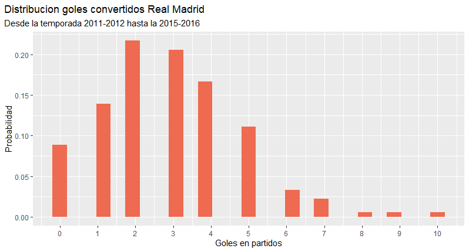

Se ve que el gráfico toma una mejor forma y en un principio parece distribuir respecto a lo esperado. Se puede apreciar un leve sesgo positivo trasladado hacia la derecha, lo que provoca además una pequeña pérdida de asimetría respecto a la moda, que se ubica entre los 2 y 3 goles.

Para corroborar que los datos siguen una distribución poisson se dió uso a la función *goodfit()* donde finalmente se obtuvo que su media es de 2.971, que son prácticamente 3 goles por partido en la gran mayoría de los casos.

Es posible notar que las dos distribuciones siguen un comportamiento similar al inicio, de manera que tienden a aumentar las probabilidades. Esto explica los índices de los promedios de goles, pues ambos equipos tienden fuertemente a marcar al menos 2 goles por partido. Esto se puede interpretar con el ejemplo de subir una escalera. Una persona está frente a una escalera, donde cada peldaño se va alejando cada vez más y cada uno de ellos significa marcar un gol. Aqui es donde se puede ir entendiendo que por cada gol que un equipo meta, es más probable marcar otro hasta un cierto punto, siendo este la media obtenida.

Ahora interesa conocer las principales situaciones de juego que llevan al gol en cada equipo, para así lograr hacer una comparativa más georeferenciada, es decir, viendo qué tipo de jugadas utilizan.

### Situaciones Barcelona

| Ubicación del campo | Situación del juego | Método de asistencia | Cantidad de goles |
| --- | --- | --- | --- |
| Centro del área | Jugada abierta | Pase | 124 |
| Centro del área | Jugada abierta | Pase en profundidad | 42 |
| Punto penal | Balón parado | Ninguno | 41 |
| Centro del área | Jugada abierta | Ninguno | 36 |
| Rango muy cercano | Jugada abierta | Pase | 32 |
| Fuera del área | Jugada abierta | Pase | 31 |
| Centro del área | Jugada abierta | Centro | 28 |
| Lado izquierdo del área | Jugada abierta | Pase | 20 |
| Rango muy cercano | Jugada abierta | Ninguno | 14 |
| Lado derecho del área | Jugada abierta | Pase | 11 |

Se puede ver rápidamente que la mayor cantidad de goles son generados mediante pases hacia el centro del área. De hecho el top 5 se conforma sólo de goles desde dentro del área, lo que significa que este equipo desarrolla sus tácticas con el objetivo principal de llegar al área rival mediante el uso de pases. Esto se puede corroborar viendo el resto de la tabla, pues los goles llegan de todos lados y de diversas maneras. Sin duda los pases son primordiales para el equipo, aunque hay que destacar que existen 2 secciones (sin considerar los penales) en donde el método de asistencia es ninguno, esto quiere decir que los goles marcados provienen de jugadas individuales.

### Situaciones Real Madrid

| Ubicación del campo | Situación del juego | Método de asistencia | Cantidad de goles |
| --- | --- | --- | --- |
| Centro del área | Jugada abierta | Pase | 87 |
| Centro del área | Jugada abierta | Centro | 49 |
| Fuera del área | Jugada abierta | Pase | 44 |
| Punto penal | Balón parado | Ninguno | 41 |
| Centro del área | Jugada abierta | Pase en profundidad | 36 |
| Lado izquierdo del área | Jugada abierta | Pase | 26 |
| Rango muy cercano | Jugada abierta | Pase | 23 |
| Centro del área | Jugada abierta | Ninguno | 22 |
| Centro del área | Tiro de esquina | Centro | 22 |
| Lado derecho del área | Jugada abierta | Pase | 15 |

Aquí sucede algo similar. Para ambos casos el primer lugar acude a la misma situación de juego y la cantidad de apariciones de jugadas que se generan mediante pases son similares, sin embargo, el real madrid utiliza en mayor medida los centros hacia el área y se atreve más a intentarlo desde fuera de esta.

Es posible concluir que ambos equipos juegan a un nivel similar. El barcelona tiende a tener un juego más colectivo para poder atentar hacia el área rival y lo hace mediante pases cortos y largos hacia una dirección clara, el centro del área. Por otro lado, el real madrid pierde en menor medida respecto a este tipo de jugadas, no obstante, esto lo logra suplir mediante un mayor manejo de jugadas aéreas y variando la ubicación del campo desde donde se marcan los goles.

# Referencias

- Clasificación mundial de clubes según la IFFHS Clasificación mundial de clubes según la IFFHS. (2021, 4 de noviembre). Wikipedia, La enciclopedia libre. Fecha de consulta: 02:22, diciembre 6, 2021 desde https://es.wikipedia.org/w/index.php?title=Clasificaci%C3%B3n_mundial_de_clubes_seg%C3%BAn_la_IFFHS&oldid=139506902.
- Información campeones de La Liga Primera División de España. (2021, 4 de diciembre). Wikipedia, La enciclopedia libre. Fecha de consulta: 02:24, diciembre 6, 2021 desde https://es.wikipedia.org/w/index.php?title=Primera_Divisi%C3%B3n_de_Espa%C3%B1a&oldid=140147738.
- Historia Leicester City Leicester City Football Club. (2021, 5 de diciembre). Wikipedia, La enciclopedia libre. Fecha de consulta: 02:25, diciembre 6, 2021 desde https://es.wikipedia.org/w/index.php?title=Leicester_City_Football_Club&oldid=140166878.
- Balón de oro Balón de Oro. (2021, 1 de diciembre). Wikipedia, La enciclopedia libre. Fecha de consulta: 02:27, diciembre 6, 2021 desde https://es.wikipedia.org/w/index.php?title=Bal%C3%B3n_de_Oro&oldid=140088470.

## Paquetes de R

- Dplyr Hadley Wickham, Romain François, Lionel Henry and Kirill Müller (2021). dplyr: A Grammar of Data Manipulation. R package version 1.0.7. https://CRAN.R-project.org/package=dplyr
- Tidyverse Wickham et al., (2019). Welcome to the tidyverse. Journal of Open Source Software, 4(43), 1686, https://doi.org/10.21105/joss.01686
- ggthemes Jeffrey B. Arnold (2021). ggthemes: Extra Themes, Scales and Geoms for ‘ggplot2’. R package version 4.2.4. https://CRAN.R-project.org/package=ggthemes
- ggplot2 H. Wickham. ggplot2: Elegant Graphics for Data Analysis. Springer-Verlag New York, 2016
- gt Richard Iannone, Joe Cheng and Barret Schloerke (2021). gt: Easily Create Presentation-Ready Display Tables. R package version 0.3.1. https://CRAN.R-project.org/package=gt
- vcd David Meyer, Achim Zeileis, and Kurt Hornik (2021). vcd: Visualizing Categorical Data. R package version 1.4-9.
- broom David Robinson, Alex Hayes and Simon Couch (2021). broom: Convert Statistical Objects into Tidy Tibbles. R package version 0.7.10. https://CRAN.R-project.org/package=broom

# Anexo

## Distribución de goles

Para cada caso se plantea un test de hipótesis de la siguiente manera:

H0: la cantidad de goles por partido sigue una distribución poisson.

H1: la cantidad de goles por partido no sigue una distribución poisson.

Nivel de significancia: 0.1.

Para ello se hará uso de la función *goodfit()* del package *vcd*. se averiguará a que distribución se le atribuye el comportamiento de los goles vistos anteriormente. Además de estimar el parámetro lambda de la distribución Poisson, esta función también realizará la prueba de bondad de ajuste y tiene como argumentos la variable de interés, el tipo de distribución y el método de ajuste que en este caso será “MinChisq” que es la opción para que realice el test Chi-cuadrado. El resultado serán los grados de libertad del estadístico, el estadístico X2 y el valor-p asociado a la prueba.

### Leicester temporada 2014-2015

```r
goles_por_partido = read.csv(file = 'PL_2014_ok.csv', encoding = 'UTF-8')

n = nrow(goles_por_partido)

LC_2014 = goles_por_partido %>% filter(equipo == 'Leicester City')

k = sort(LC_2014$goles)
gf<-goodfit(k, type = "poisson", method = "MinChisq")
gf$par
```

```
## $lambda
## [1] 1.221805
```

```r
summary(gf)
```

```
##
##   Goodness-of-fit test for poisson distribution
##
##              X^2 df  P(> X^2)
## Pearson 3.882214  4 0.4221811
```

Valor-p > 0.1 por lo tanto no rechazamos la hipótesis nula.

### Leicester temporada 2015-2016

```r
goles_por_partido = read.csv(file = 'PL_2015_ok.csv', encoding = 'UTF-8')

n = nrow(goles_por_partido)

LC_2015 = goles_por_partido %>% filter(equipo == 'Leicester City')
k = sort(LC_2015$goles)
gf<-goodfit(k, type = "poisson", method = "MinChisq")
gf$par
```

```
## $lambda
## [1] 1.850533
```

```r
summary(gf)
```

```
##
##   Goodness-of-fit test for poisson distribution
##
##              X^2 df  P(> X^2)
## Pearson 3.752559  3 0.2894527
```

Valor-p > 0.1 por lo tanto no rechazamos la hipótesis nula.

### Barcelona temporadas 2011-2012 hasta la 2015-2016

```r
goles_equipos= read.csv(file = 'La_liga_goal_per_mach.csv', encoding = 'UTF-8')

barca = goles_equipos %>% filter(equipo == 'Barcelona')
k = sort(barca$goles)
gf<-goodfit(k, type = "poisson", method = "MinChisq")
gf$par
```

```
## $lambda
## [1] 2.920188
```

```r
summary(gf)
```

```
##
##   Goodness-of-fit test for poisson distribution
##
##              X^2 df   P(> X^2)
## Pearson 14.42507  7 0.04411743
```

Valor-p < 0.1 por lo tanto rechazamos la hipótesis nula.

### Real Madrid temporadas 2011-2012 hasta la 2015-2016

```r
real_madrid = goles_equipos %>% filter(equipo == 'Real Madrid')
k = sort(real_madrid$goles)
gf<-goodfit(k, type = "poisson", method = "MinChisq")
gf$par
```

```
## $lambda
## [1] 2.971262
```

```r
summary(gf)
```

```
##
##   Goodness-of-fit test for poisson distribution
##
##              X^2 df  P(> X^2)
## Pearson 11.06675  9 0.2711611
```

Valor-p > 0.1 por lo tanto no rechazamos la hipótesis nula.